# Combining plots in ggplot2

The ggplot2 package doesn’t providing function to arrange multiples plots in a single figure, but there are some packages, that allow combine multiples plots into a single figure with custom layouts, width, height, such as cowplot, gridExtra, patchwork

# Sample plots

Let’s create four different plots and assign them to objects named **p1**, **p2**, **p3** and **p4**. You can use any other names.

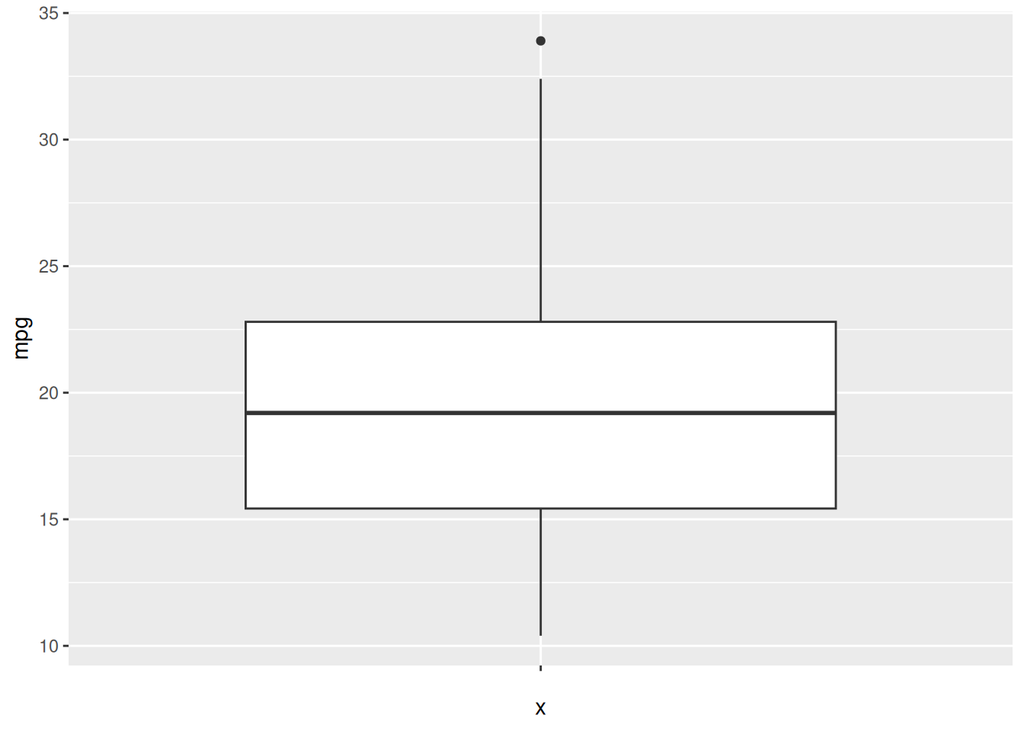

```r
library(ggplot2)

#Data
mtcars->df

# Box plot
p1 <- ggplot(df, aes(x = "", y = mpg)) +
  geom_boxplot()

# Density plot
p2 <- ggplot() +
  stat_function(fun = dnorm, geom = "density",
                xlim = c(-3, 3), fill = "white")

# Line chart
p3 <- ggplot(df, aes(x = mpg, y = disp)) +
  geom_line(color = "gray20")

# Scatter plot
p4 <- ggplot(df, aes(x = hp, y = wt)) +
  geom_point(color = "gray20")

# View the plots
p1
```

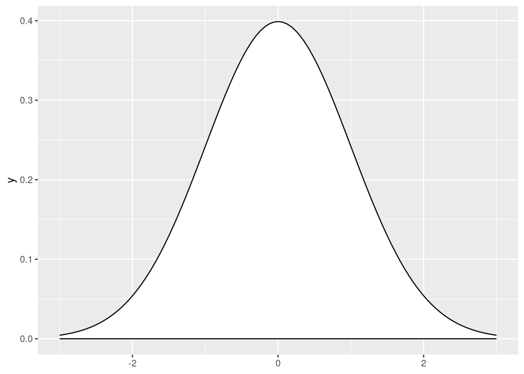

```r
p2
```

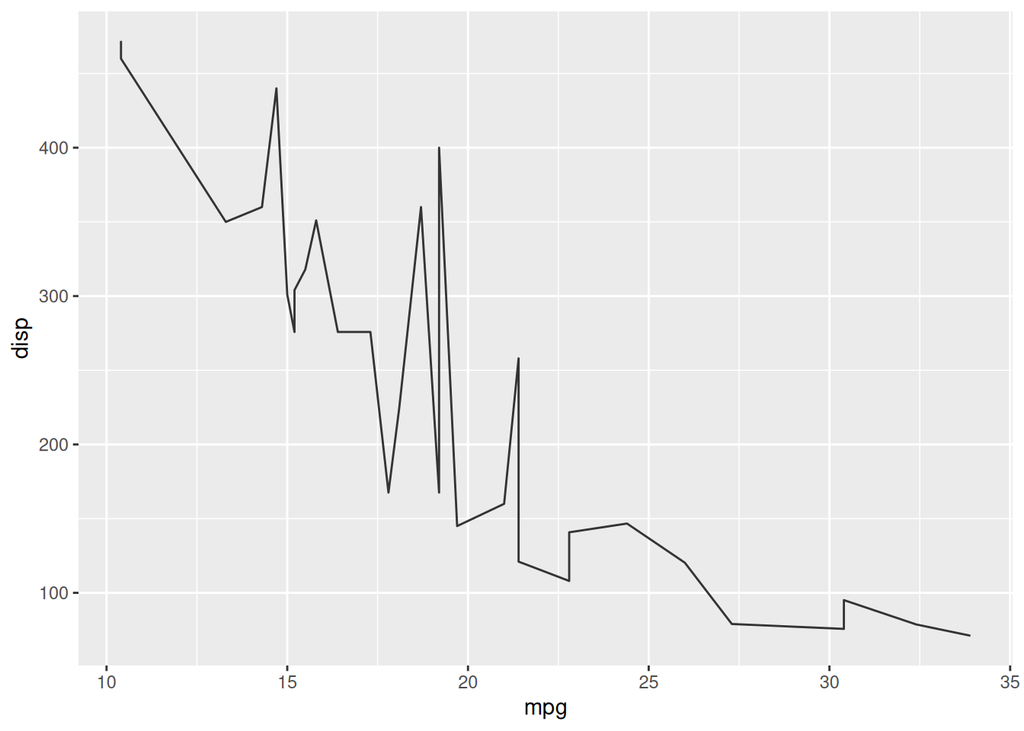

```r
p3
```

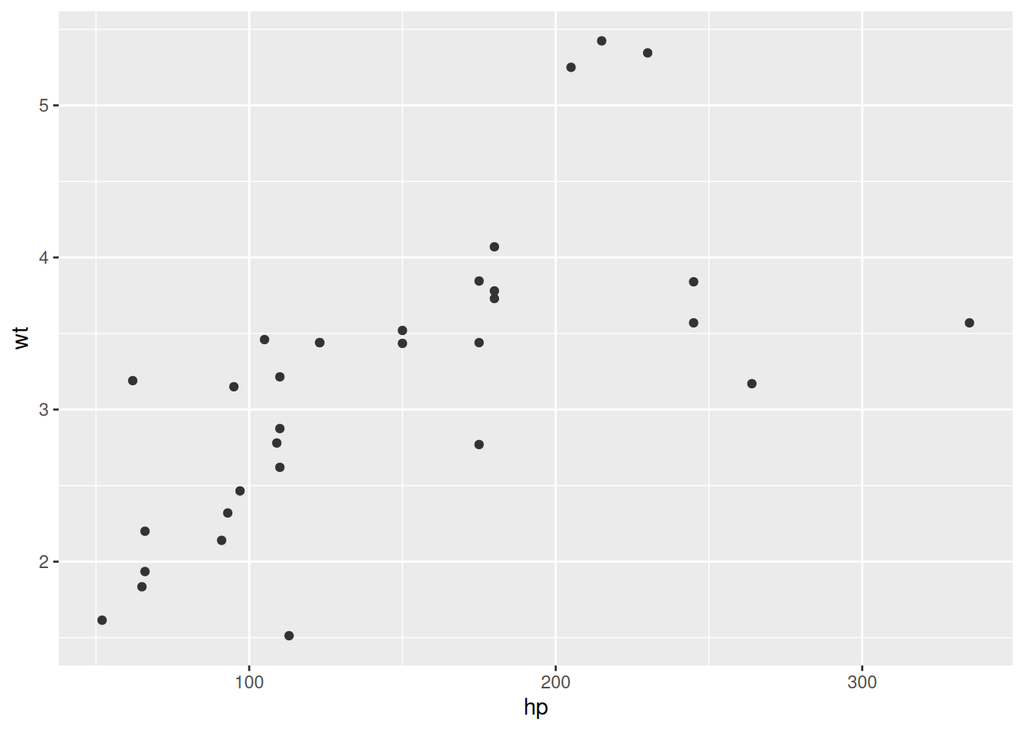

```r
p4
```

# gridExtra

The gridExtra package provides the grid.arrange function to combine several plots on a single figure.

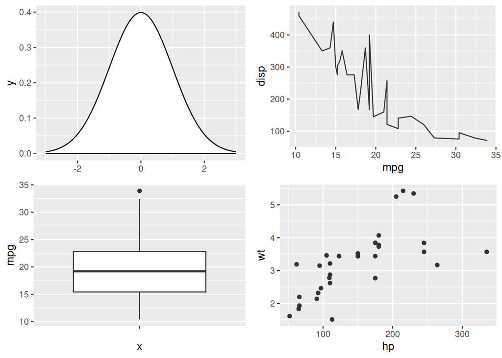

```r
# install.packages("gridExtra")
library(ggplot2)
library(gridExtra)

# Combine the plots with gridExtra
grid.arrange(p2, p3, p1, p4)
```

You can also specify the number of rows with **nrow**, the number of columns with **ncol**, and the sizes with **widths** and **heights** and also we can add labels at the top, bottom, left and right of the figures.

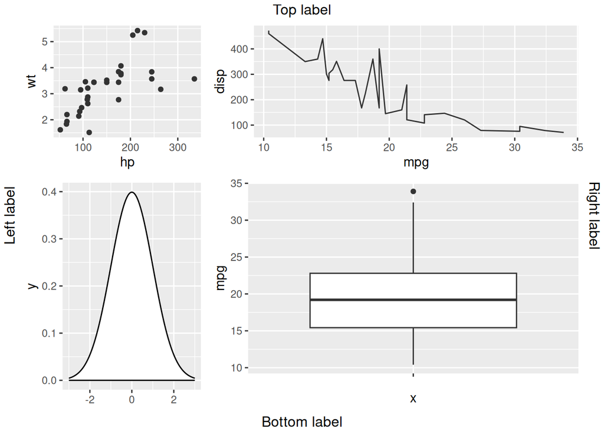

```r
library(ggplot2)
library(gridExtra)

# Combine the plots
grid.arrange(p4, p3, p2, p1,
             top = "Top label", bottom = "Bottom label",
             left = "Left label", right = "Right label",
             widths = c(1, 2), heights = c(2, 3))
```

We can create a layout matrix indicating the positions for each plot and use the layout_matrix function in order to specify the desired layout.

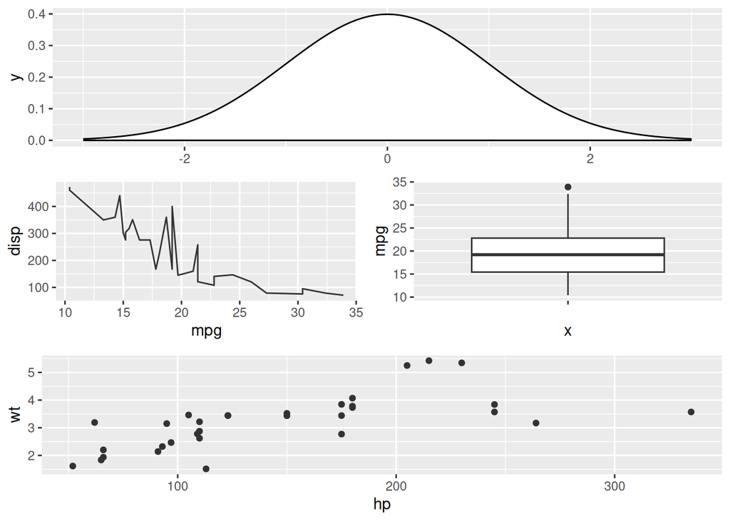

```r
library(ggplot2)
library(gridExtra)

# layout
layout <- matrix(c(1, 1,
                   2, 3,
                   4, 4), ncol = 2, byrow = TRUE)

grid.arrange(p2, p3, p1, p4,
             layout_matrix = layout)
```

# patchwork

## Combining ggplot2 plots

patchwork is designed to combine ggplot2 plots into the same figure easily with using the + operator to combine the charts.

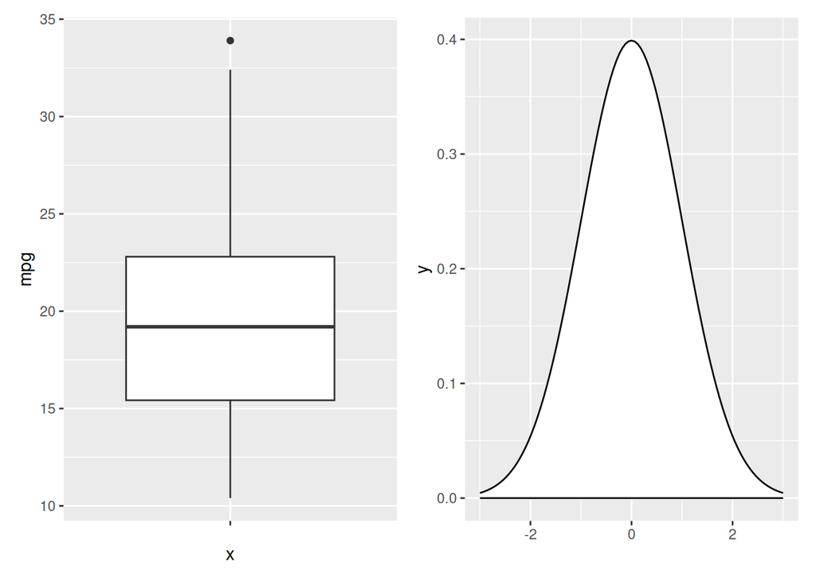

```r
# install.packages("patchwork")
library(ggplot2)
library(patchwork)

# Combine the plots
p1 + p2
```

## Controlling the layout

If you want to customize the number of rows or columns of the figure you can use the plot_layout function. Also you can also specify the widths and heights of the plots with widths and heights arguments.

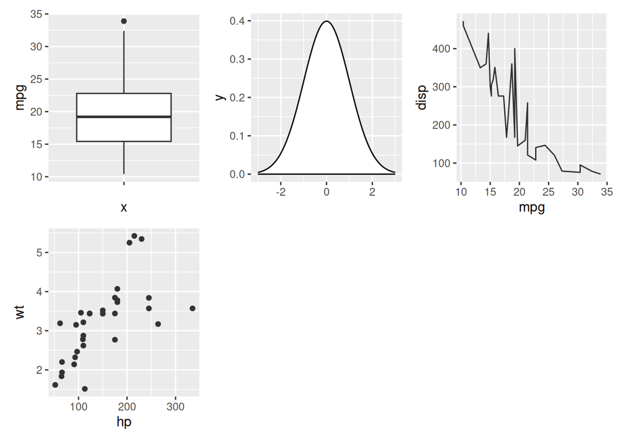

```r
library(ggplot2)
library(patchwork)

# Combine the plots
p1 + p2 + p3 + p4 +
  plot_layout(ncol = 3)
```

The most interesting functionality of the plot_layout function is that you can create a custom layout design as shown in the example below, where 1, 2, 3 and 4 represents the locations for p1,p2, p3 and p4, respectively, and # represents an empty space. Recall that you can use numbers but also letters to represent the plot locations.

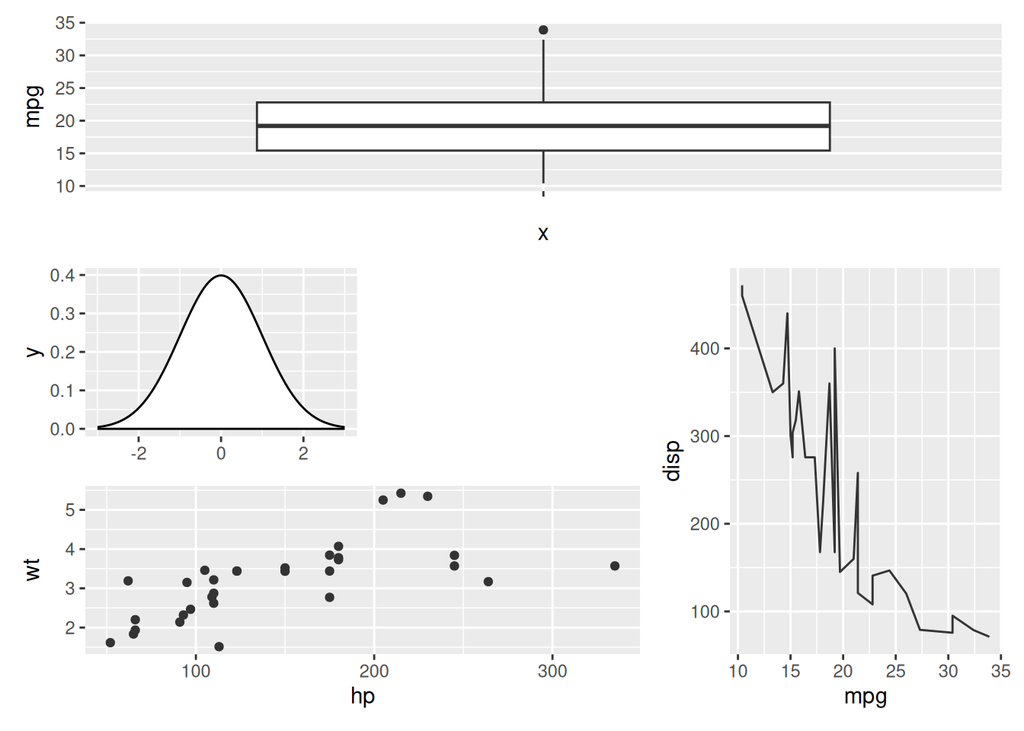

```r
library(ggplot2)
library(patchwork)

# Combine the plots with a custom layout
p1 + p2 + p3 + p4 +
  plot_layout(design ="111
                       2#3
                       443")
```

### The wrap_plots function

Sometimes you can’t use the + operator programatically, so if you don’t know the number of plots beforehand you can use the wrap_plots function and pass a list of plots to it. This function also allows specifying the number of rows and columns, the sizes and the custom layouts.

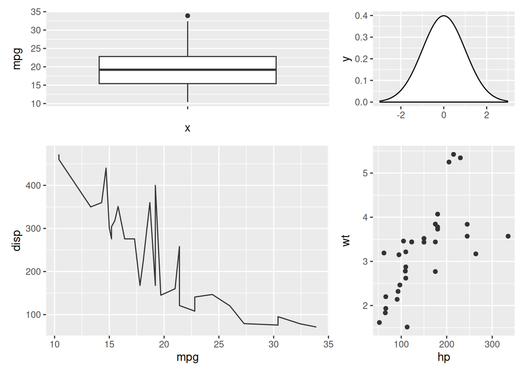

```r
library(ggplot2)
library(patchwork)

# Combine the plots
wrap_plots(p1, p2, p3, p4,
           ncol = 2, nrow = 2,
           widths = c(1, 0.5), heights = c(0.5, 1))
```

### Adding spacers

When creating a custom layout you can use # to add spaces, as shown in one of the previous examples, but if you are using + there is also a function named plot_spacer to add spaces or gaps between plots.

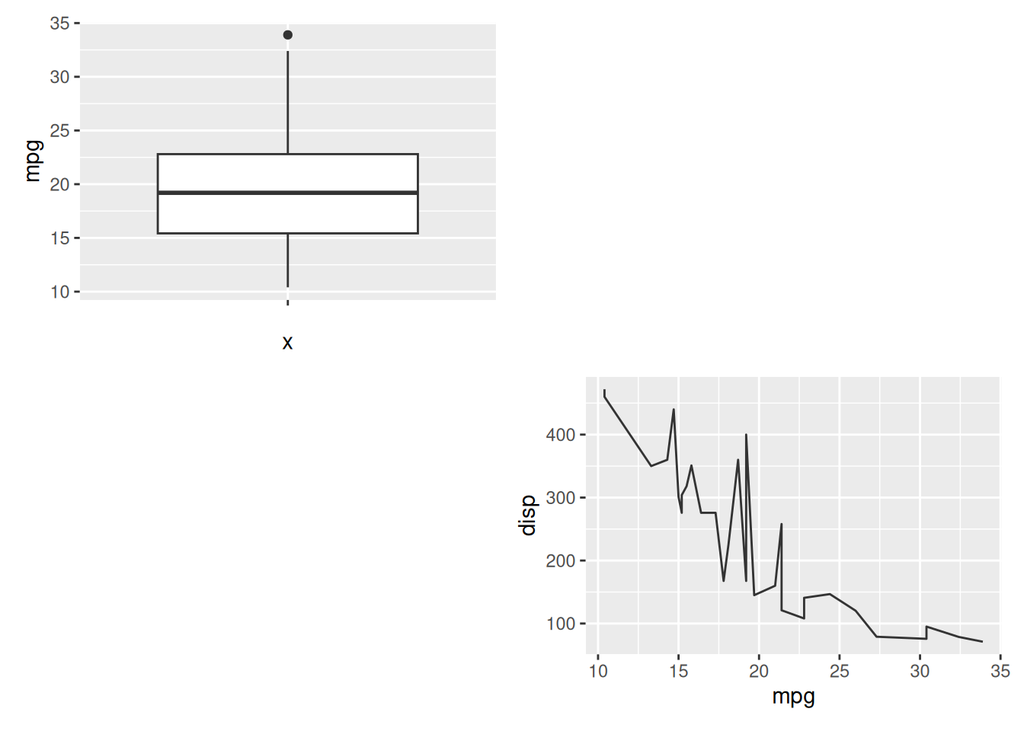

```r
library(ggplot2)
library(patchwork)

# Plots with spaces
p1 + plot_spacer() + plot_spacer() + p3
```

## Operators

The patchwork package also provides two operators to place plots beside each other or to stack them.

### Arranging ggplot2 plots in rows (beside each other)

The | operator places plots in a row. This operator is similar to + when you have two plots but | will place all plots in a single row while + will try to create a square layout if possible.

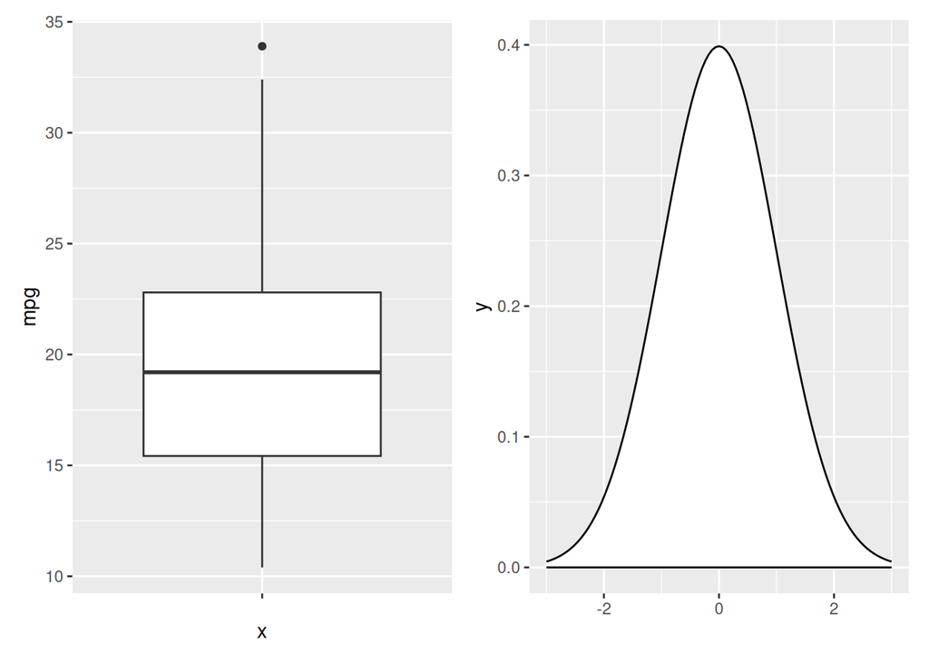

```r
library(ggplot2)
library(patchwork)

# Combine the plots in rows
p1 | p2
```

### Arranging ggplot2 plots in columns (stacked)

The / operator stacks the ggplot2 plots into columns without the need of using the plot_layout function and specifying ncol = 1.

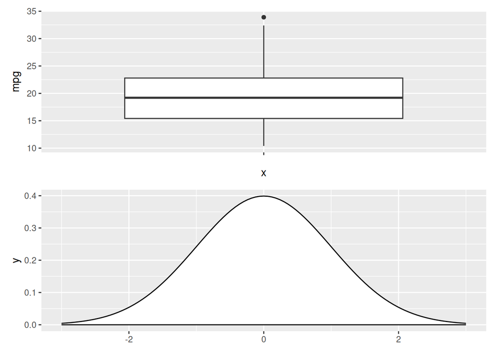

```r
library(ggplot2)
library(patchwork)

# Combine the plots as column
p1 / p2
```

You can create complex layouts. The | and / operators can be use to create complex layouts combining plots. In the following example we are creating a layout with two plots at the top and one wider at the bottom.

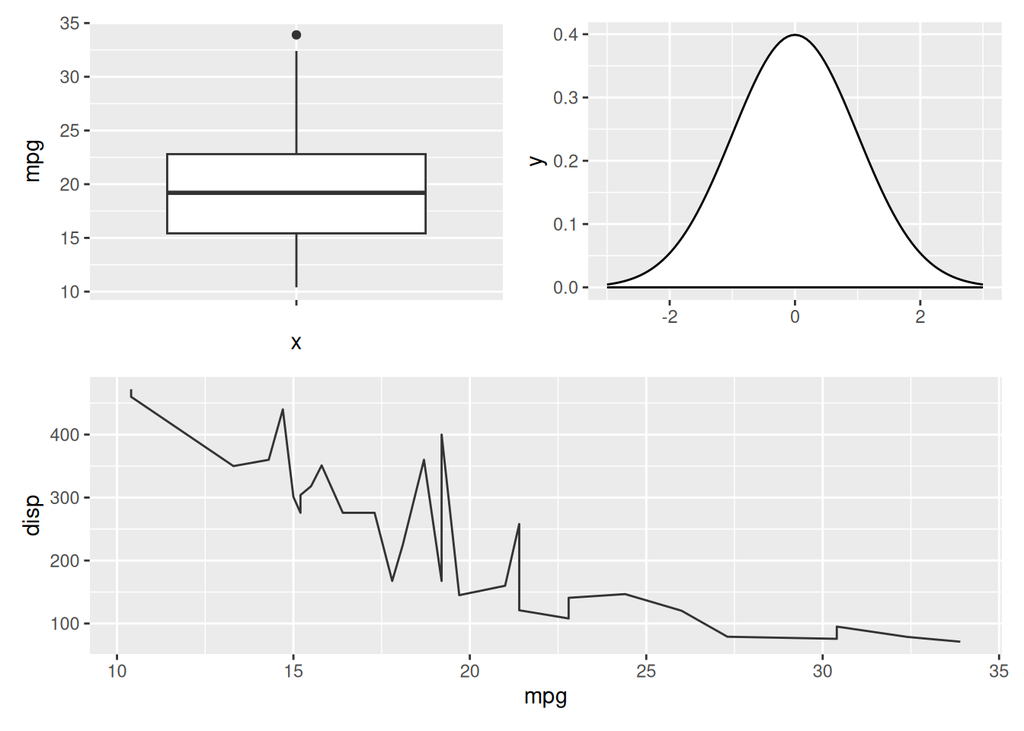

```r
library(ggplot2)
library(patchwork)

# Two plots on top and one at the bottom
(p1 | p2) / p3
```

The following example is similar to the previous, but with one plot at the left and two at the right.

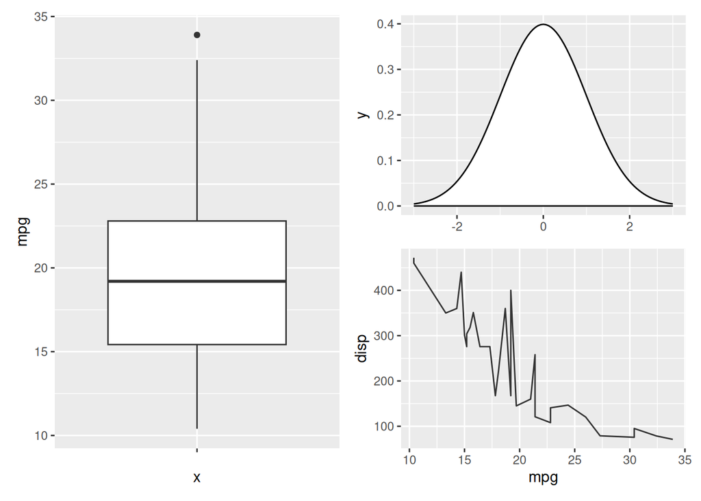

```r
library(ggplot2)
library(patchwork)

# One plot at the left and two at the right
p1 | (p2 / p3)
```

## Titles and labels

### Title for all the plots

You can add a title, subtitle and captions to all plots with the plot_annotation function.

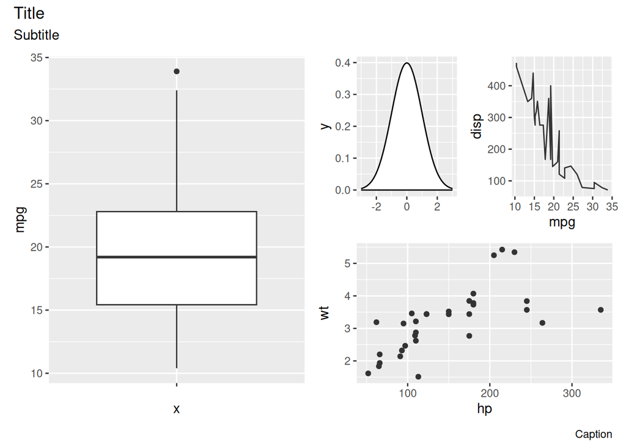

```r
library(ggplot2)
library(patchwork)

# Title for the combined plots
p1 + ((p2 | p3) / p4) +
plot_annotation(title = "Title",
                subtitle = "Subtitle",
                caption = "Caption")
```

The plot_annotation function can also be used to label each plot individually with the tags_level argument. Possible options are “1” for numbers, “a” for lowercase letters, “A” for uppercase letters, “i” for lowercase Roman numerals, “I” for uppercase Roman numerals or a vector with your own tags.

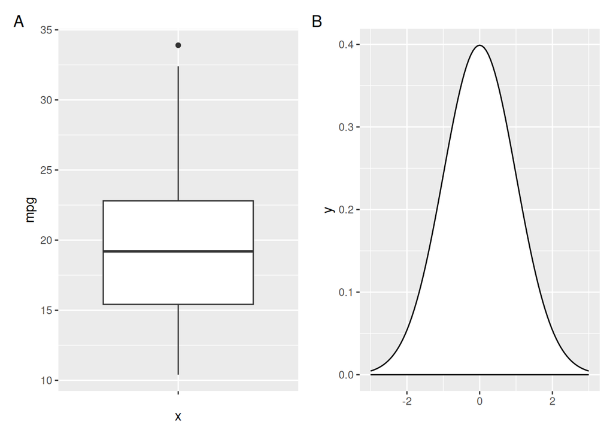

```r
library(ggplot2)
library(patchwork)

# Labels for each plot
p1 + p2 + plot_annotation(tag_levels = "A")
```

The labels can be customized with the tag_prefix, tag_suffix and tag_sep arguments.

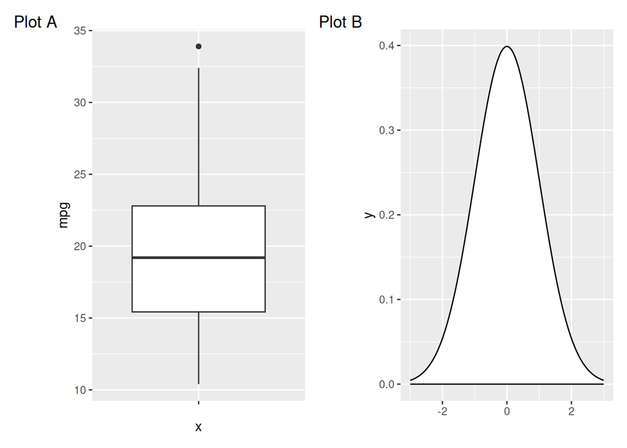

```r
library(ggplot2)
library(patchwork)

# Labels for each plot
p1 + p2 + plot_annotation(tag_levels = "A", tag_prefix = "Plot ")
```

## Adding more layers

The figures created with patchwork behave the same way as a ggplot2 object, so you can add new layers as with normal plots, but the layer will be applied to the last added plot.

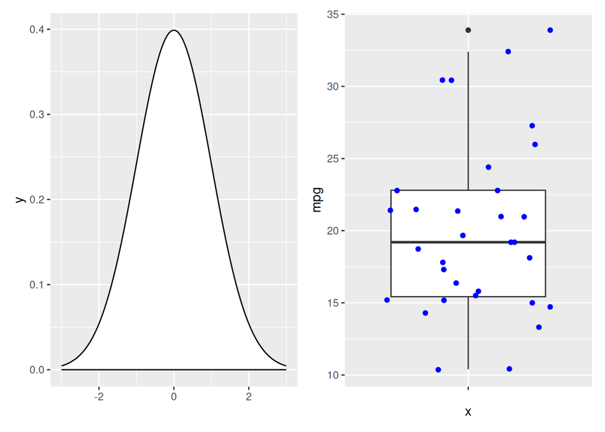

```r
library(ggplot2)
library(patchwork)

# Add a new layer
p2 + p1 +
  geom_jitter(color = "blue")
```

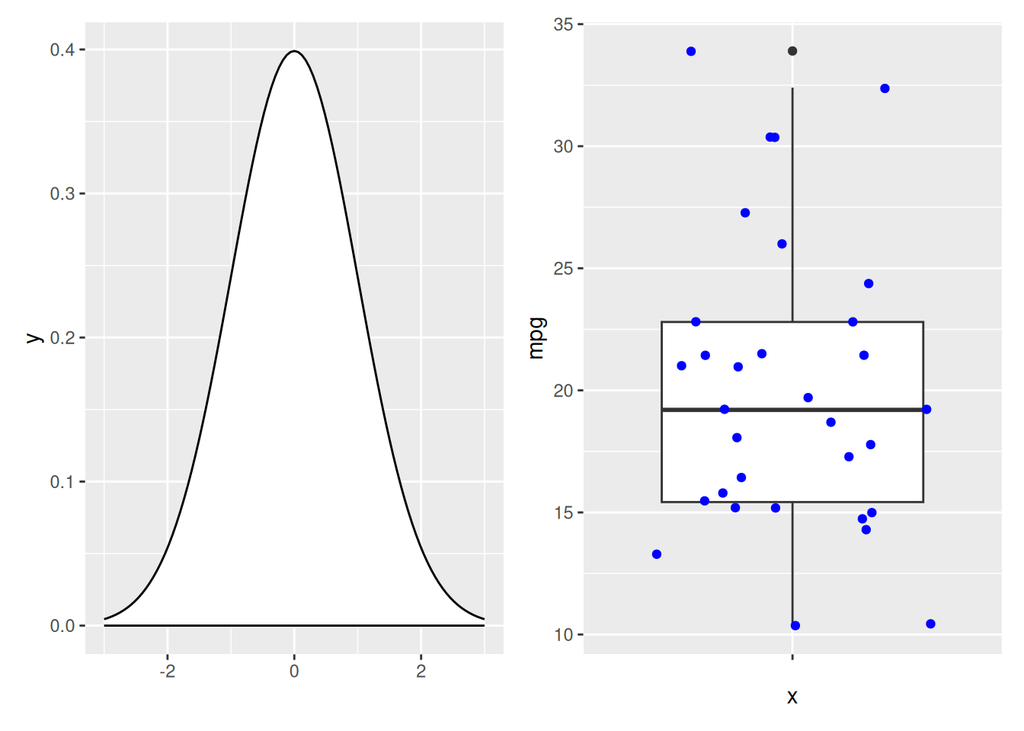

```r
# Equivalent to:
p <- p2 + p1
p + geom_jitter(color = "blue")
```

If you want to customize other than the last plot added you can add the new layer to it or save the patchwork, access the desired element and customize it, as shown in the following example.

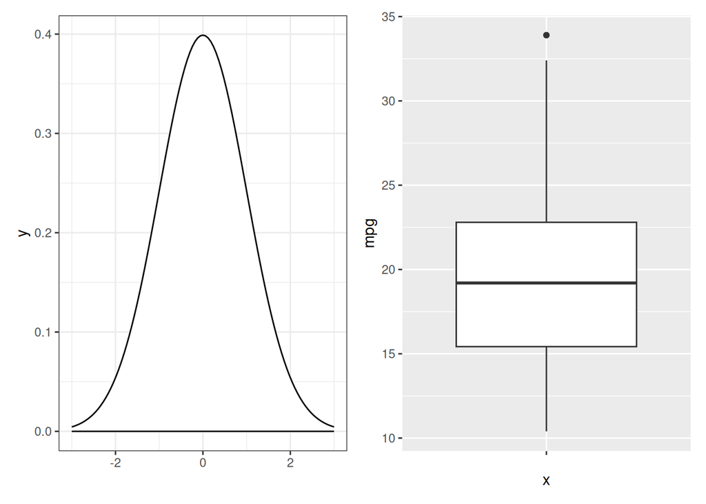

```r
library(ggplot2)
library(patchwork)

# Add a new layer to the first plot
p2 + theme_bw() + p1
```

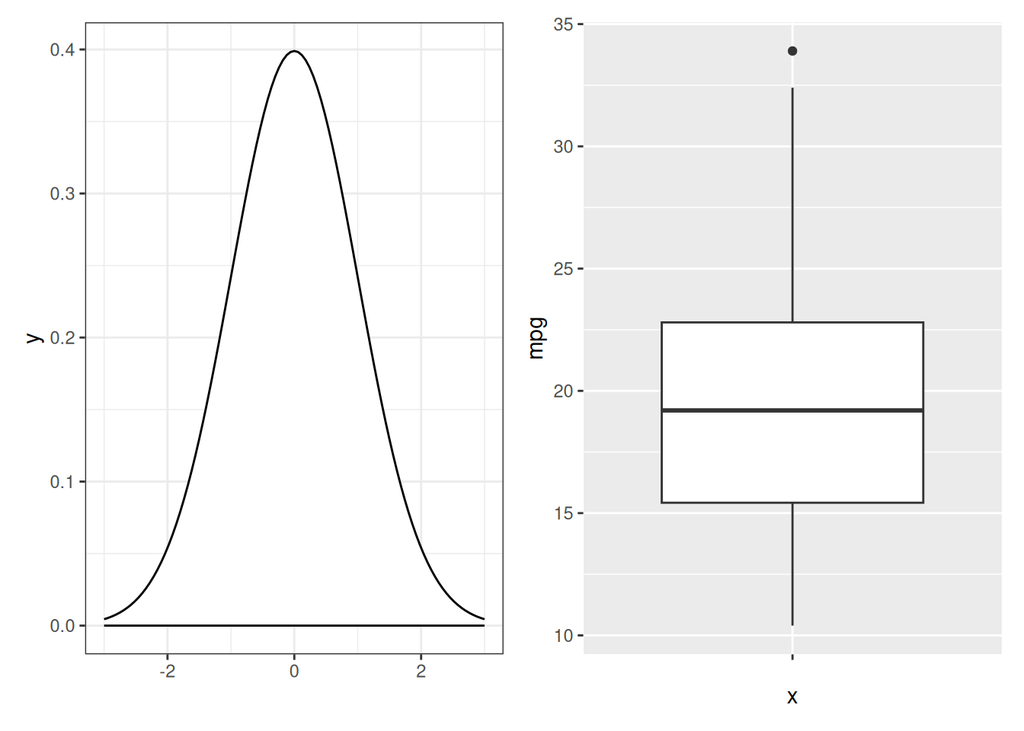

```r
# Equivalent to:
p <- p2 + p1
p[[1]] <- p[[1]] + theme_bw()
p
```

### Modifying all plots at the same time

patchwork also provides the & operator to modify all the plots at the same time to set the same theme for all plots at the same time.

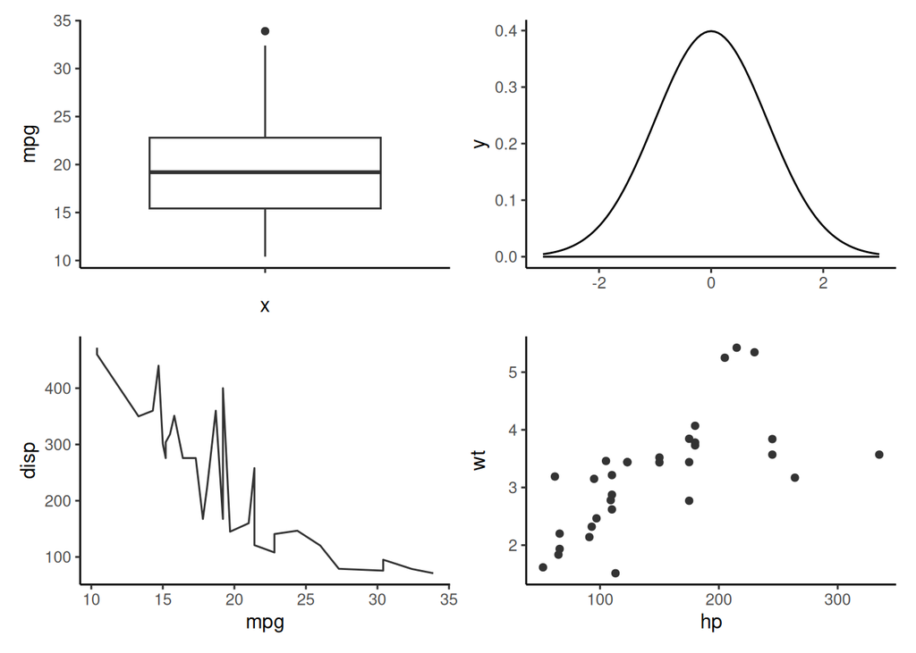

```r
library(ggplot2)
library(patchwork)

# Change the theme for all plots
p1 + p2 + p3 + p4 & theme_classic()
```

## Adding tables and text

When adding base R plots and ggplot2 plots patchwork won’t be able to align the plots, so you will need to customize the margins for one of the plots and try to fine tune the values until you reach a good alignment.

Making use of the tableGrob function from the gridExtra package you can add a table to a layout created with patchwork.

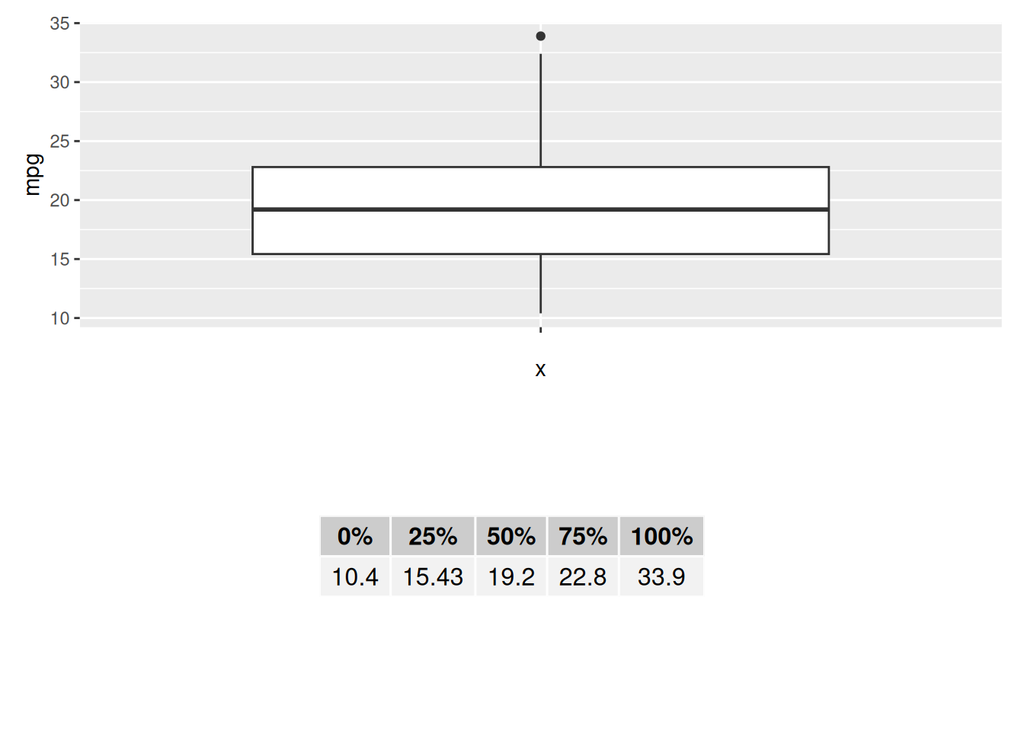

```r
# install.packages("gridExtra")
library(ggplot2)
library(patchwork)
library(gridExtra)

tab <- t(round(quantile(df$mpg), 2))

# ggplot2 with table
p1 / tableGrob(tab)
```

You can also use the textGrob function from gridExtra to add a text to the layout, but note that if you want the text to be the first element you will need to use the wrap_elements function.

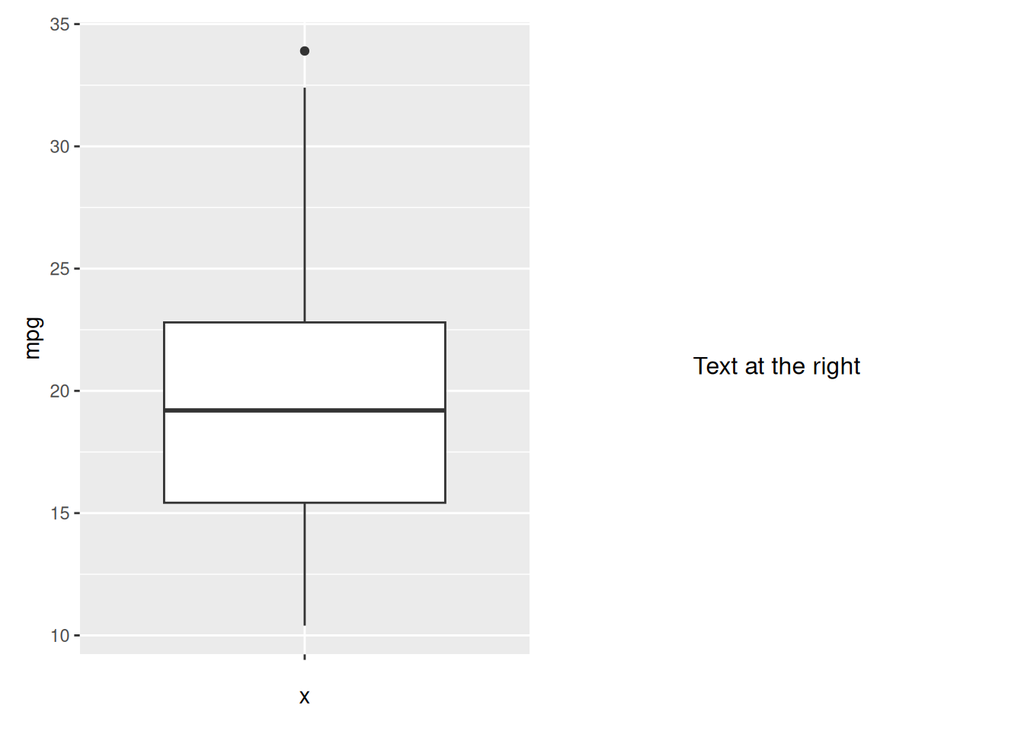

```r
library(ggplot2)
library(patchwork)
library(grid)

# ggplot2 with text
p1 + textGrob("Text at the right")
```

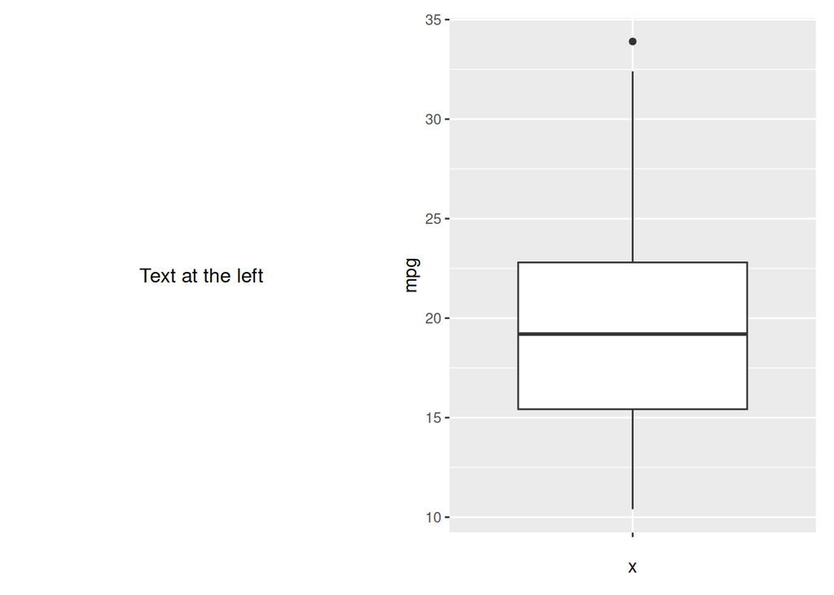

```r
# To put the text first use:
wrap_elements(textGrob("Text at the left")) + p1
```

# cowplot

The cowplot package combinign plots using the plot_grid function.

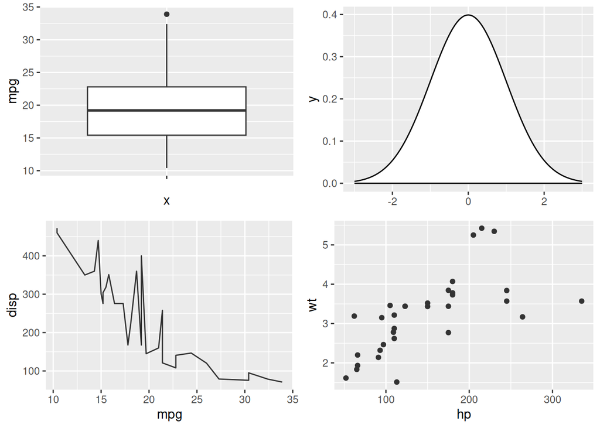

```r
# install.packages("cowplot")
library(ggplot2)
library(cowplot)
plot_grid(p1, p2, p3, p4)
```

## Aligning the plots

The **plot_grid function also customize the number of rows and columns of plots with the nrow and ncol arguments.**

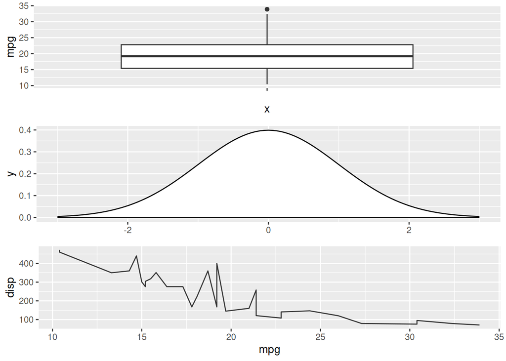

```r
library(ggplot2)
library(cowplot)

plot_grid(p1, p2, p3, ncol = 1)
```

## Adding labels to each plot

If you want to label each plot individually you can make use the labels argument of the function, where you can specify a vector of labels or use the “A” or “a” keywords for automatic labels in uppercase or lowercase, respectively. The function also provides several arguments to customize the style of the texts.

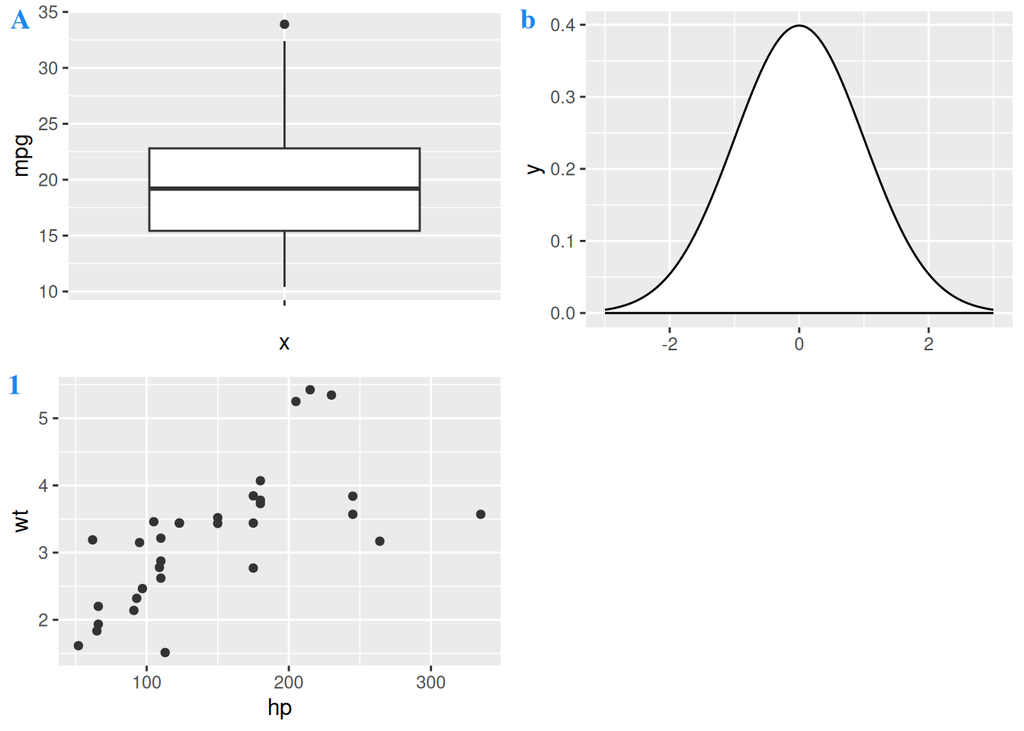

```r
library(ggplot2)
library(cowplot)

plot_grid(p1, p2, p4,
          labels = c("A", "b", 1),
          label_fontfamily = "serif",
          label_fontface = "bold",
          label_colour = "dodgerblue2")
```

## Mixing plots with cowplot

With cowplot you can also create more complex layouts combining plot_grid functions, as shown in the example below, where we are creating a layout with two plots at the bottom and one at the top.

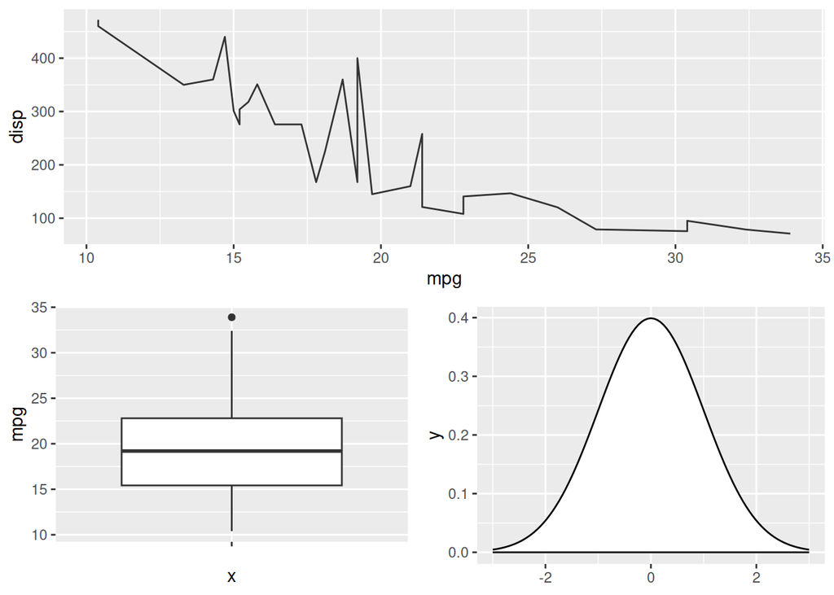

```r
library(ggplot2)
library(cowplot)

# Grid layout with cowplot
plot_grid(p3, plot_grid(p1, p2), ncol = 1)
```